# Chi-Square Exploration/Tutorial Answer Key

Madeleine Guettler

2023-12-11

```r
# Load any R Packages you may need
# If have not installed these packages before need to go into console to install
#e.g. install.packages("tidyverse","mosaic", "infer")
library(tidyverse)
library(mosaic)
library(infer)
```

# Import Dataset

The data set used in this tutorial is a data set exploring shopper sessions online and having outcome variable Revenue, meaning a shopper bought something.

```r
online_shoppers_intention <- read_csv("online_shoppers_intention.csv")
```

# Data exploration

For this tutorial there are two questions to explore. They are: 1. If there is a relationship between weekend and revenue. Where hypotheses are: $H_{0}$: There is no relationship between weekend and revenue $H_{a}$: There is a relationship between weekend and revenue

2. If there is a relationship between month and revenue. Where hypotheses are: $H_{0}$: There is no relationship between month and revenue $H_{a}$: There is a relationship between weekend and revenue

There will be a bonus question that can be done on your own. There will be an attached answer key.

**Question 1 Data Visualization**

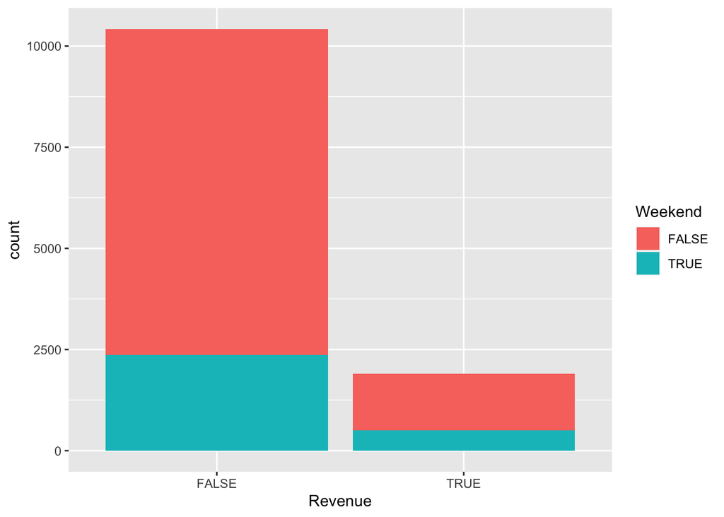

```r
gf_bar(~Revenue, fill = ~Weekend, data = online_shoppers_intention)
```

```r
tally(Weekend ~ Revenue, data = online_shoppers_intention)
```

```
##        Revenue
## Weekend TRUE FALSE
##   TRUE   499  2369
##   FALSE 1409  8053
```

```r
#if want to see proportions
tally(Weekend ~ Revenue, format = 'proportion', data = online_shoppers_intention)
```

```
##        Revenue
## Weekend      TRUE     FALSE
##   TRUE  0.2615304 0.2273076
##   FALSE 0.7384696 0.7726924
```

```r
diff = 0.2615304 - 0.2273076
diff
```

```
## [1] 0.0342228
```

Just in some preliminary exploration of the data it appears that on the weekend there are slightly more sales than on weekdays where there is a difference of 0.0342. There are significantly less observations where individual bought an item.

Before we can calculate our chi-square statistic, we must see if the following conditions were met. 1. The variables are all categorical 2. The observations are independent of one another 3. The expected cell count for each is at least 5

We can do find our expected value through the chisq.test() function

```r
ChisqTest = chisq.test(tally(Weekend ~ Revenue, data = online_shoppers_intention))
ChisqTest$expected
```

```
##        Revenue
## Weekend      TRUE    FALSE
##   TRUE   443.8073 2424.193
##   FALSE 1464.1927 7997.807
```

The variables are category, the observations are independent, and our expected cell count is >= 5. We are ready to look at our p-value and test statistic. If we wanted to look at goodness of fit, we would examine our test statistic. But in this case we’re going to do a test of independence and primarilyfocus on our p-value

Lets go ahead and see what our p-value and test statistic is.

Note: while R calculates degree of freedom for us, in order to find degree of freedom we would do: df = (r-1)(c-1) df = (2-1)*(2-1) = 1

```r
chisq.test(tally(Weekend ~ Revenue, data = online_shoppers_intention))
```

```
##
##  Pearson's Chi-squared test with Yates' continuity correction
##
## data:  tally(Weekend ~ Revenue, data = online_shoppers_intention)
## X-squared = 10.391, df = 1, p-value = 0.001266
```

The observed test statistic is 10.391. Assuming 5% significance level, with a p-value of 0.001266 < 0.05, we are able to reject our null hypothesis that no relationship between weekend and revenue. Instead we can conclude our alternative hypothesis that there is a relationship between weekend and revenue.

# Visualizing Chi-Square Distribution

If we wanted to visualize a simulation with our data we could do this in a few steps.

```r
#Another way to calculate our chi-square test statistic X^2 for month and revenue. Will use in visualization.
chisq_stat1 = online_shoppers_intention %>%
  specify(Revenue ~ Weekend, success = 'TRUE') %>% #specifying which columns in dataframe are relevant
  calculate(stat = "Chisq")
origin_distribution = online_shoppers_intention %>%
  specify(Revenue ~ Weekend, success = 'TRUE') %>%
  hypothesize(null = "independence") %>% #In our hypothesize function we are declaring that our two variables specified in the specify line are independent.
  generate(reps = 1000, type = "permute") %>% #Here we are generating 1000 observations simulated distribution
  calculate(stat = "Chisq") #calculated chi-square test statistic again
```

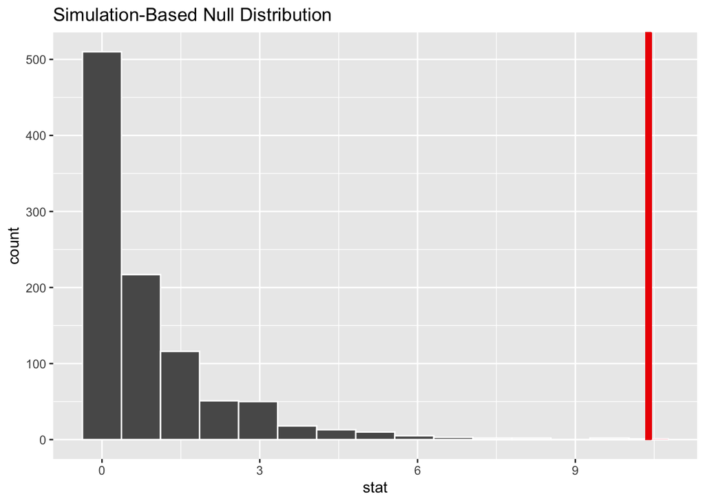

```r
visualize(origin_distribution) +
  shade_p_value(obs_stat = chisq_stat1, direction = "greater") #visualizing our distribution
```

As our simulated distribution assumes that our two variables are independent, we can see that there is a maybe one observation that does indeed fall into 10.391 test statistic but in general with a p-value <0.05, it does make sense to reject our null hypothesis.

**Question 2 Visualization**

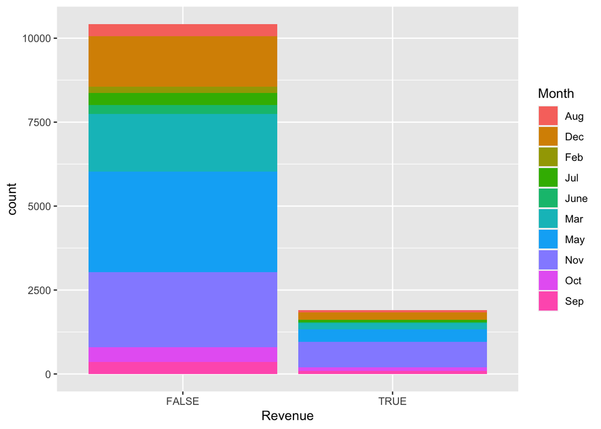

```r
gf_bar(~ Revenue, fill = ~Month, data = online_shoppers_intention)
```

```r
tally(Month ~ Revenue,format = 'proportion', data = online_shoppers_intention)
```

```
##       Revenue
## Month         TRUE       FALSE
##   Aug  0.039832285 0.034254462
##   Dec  0.113207547 0.144981769
##   Feb  0.001572327 0.017367108
##   Jul  0.034591195 0.035118020
##   June 0.015199161 0.024851276
##   Mar  0.100628931 0.164555747
##   May  0.191299790 0.287756669
##   Nov  0.398322851 0.214738054
##   Oct  0.060272537 0.041642679
##   Sep  0.045073375 0.034734216
```

Degree of Freedom calculation: df = (10-1)(2-1) = 9

# Condition Met Check

Are all three conditions met for chi-square test? 1. The variables are all categorical 2. The observations are independent of one another 3. The expected cell count for revenue category is at least 5

```r
test2 = chisq.test(tally(Month ~ Revenue, data = online_shoppers_intention))
test2$expected
```

```
##       Revenue
## Month       TRUE     FALSE
##   Aug   67.00438  365.9956
##   Dec  267.24380 1459.7562
##   Feb   28.47299  155.5270
##   Jul   66.84964  365.1504
##   June  44.56642  243.4336
##   Mar  295.09781 1611.9022
##   May  520.56058 2843.4394
##   Nov  463.92409 2534.0759
##   Oct   84.95474  464.0453
##   Sep   69.32555  378.6745
```

It looks like all expected values meet requirement of being >= 5.

# P value and test statistic

Find the test statistic and p-value. Based off p-value what conclusion can you make about the relationship between Months and Revenue.

```r
chisq.test(tally(Month ~ Revenue, data = online_shoppers_intention))
```

```
##
##  Pearson's Chi-squared test
##
## data:  tally(Month ~ Revenue, data = online_shoppers_intention)
## X-squared = 384.93, df = 9, p-value < 2.2e-16
```

The test statistic here of 384.93 is quite large which is not unexpected considering the high degree of freedom for this distribution. The p-value < 2.2e-16 is significantly less than the 5% significance level allowing for the rejection of the null hypothesis that no relationship between month and revenue. Instead we can conclude our alternative hypothesis that there is a relationship or dependency between month and revenue.

# Visualization of chi-square distribution simulation

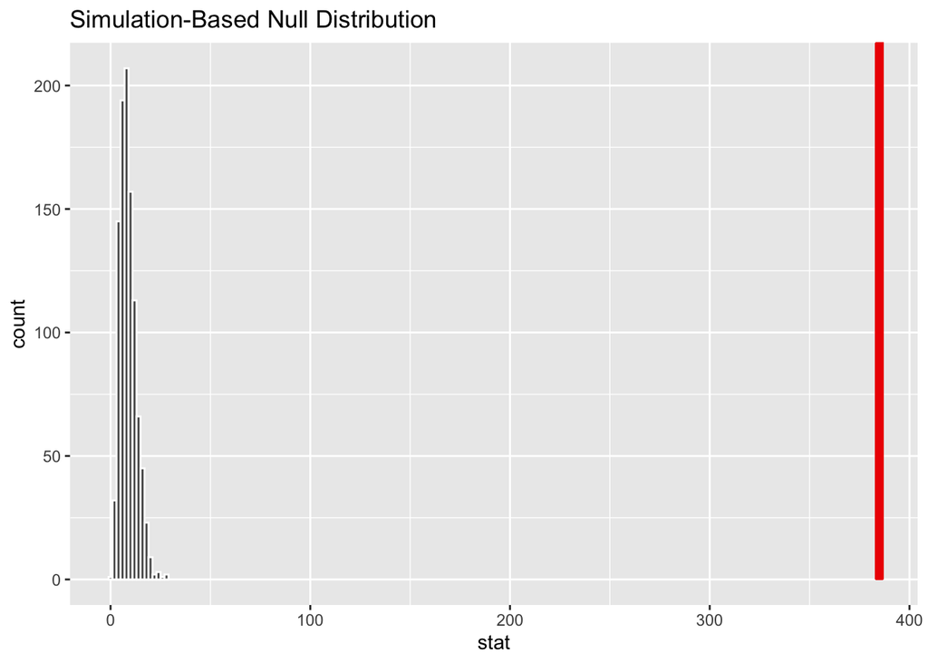

```r
chisq_stat = online_shoppers_intention %>%
  specify(Month ~ Revenue) %>%
  calculate(stat = "Chisq")

origin_distribution = online_shoppers_intention %>%
  specify(Month ~ Revenue) %>%
  hypothesize(null = "independence") %>%
  generate(reps = 1000, type = "permute") %>%
  calculate(stat = "Chisq")

visualize(origin_distribution) +
  shade_p_value(obs_stat = chisq_stat, direction = "greater")
```

In this simulation we have used our test statistic 384.93 as a marker of 5% significance level, and again setting our simulation to month and revenue being independent. And see that there doesn’t seem to be any values falling into upper tail area. This simulation shows well why p-value is so tiny. As there is just such a difference.

# Bonus Question

Now let’s look at our three months that had the highest revenue proportions.

Let’s set our hypotheses $H_{0}$: There is no relationship between month and revenue $H_{a}$: there is a relationship between month and revenue

# Data Prep

I will do data prep for you of filtering out observations to only include months May, December, and November.

```r
month_data = online_shoppers_intention %>%
  subset(Month == c('Nov', 'Dec', 'May'))
#View(month_data) If want to view comment out
```

# Data Visualization

Create a bar graph and two contingency tables (proportion, and count).

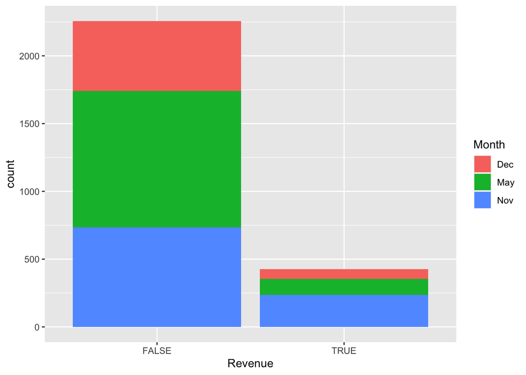

```r
#write bar graph and contingency table code here
gf_bar(~Revenue, fill = ~Month, data = month_data)
```

```r
tally(Month ~ Revenue, data = month_data)
```

```
##      Revenue
## Month TRUE FALSE
##   Dec   72   518
##   May  118  1003
##   Nov  235   736
```

```r
tally(Month ~ Revenue, format = 'proportion', data = month_data)
```

```
##      Revenue
## Month      TRUE     FALSE
##   Dec 0.1694118 0.2295082
##   May 0.2776471 0.4443952
##   Nov 0.5529412 0.3260966
```

```r
0.5529412-0.2776471
```

```
## [1] 0.2752941
```

It appears that May has the highest false rate from the three variables. November still has the highest purchase rate, but May actually has a higher purchase rate than December does. November has a difference of 0.275 in purchase rate from May’s rate.

# Check if expected values >= 5

```r
chisq3 = chisq.test(tally(Month ~ Revenue, data = month_data))
chisq3$expected
```

```
##      Revenue
## Month      TRUE    FALSE
##   Dec  93.49366 496.5063
##   May 177.63796 943.3620
##   Nov 153.86838 817.1316
```

Every cell has an expected rate >= 5 so can do chi-square independence test.

```r
chisq.test(tally(Month ~ Revenue, data = month_data))
```

```
##
##  Pearson's Chi-squared test
##
## data:  tally(Month ~ Revenue, data = month_data)
## X-squared = 80.499, df = 2, p-value < 2.2e-16
```

At 5% significance level, with a p-value < 2.2e-16, that is less than 0.05, we can reject our null hypothesis that no relationship between month and revenue and conclude alternative hypothesis that there is a relationship between month and revenue. Because our degree of freedom is significantly lower as well it makes sense that our test statistic quite a bit lower with a value of 80.499.

# Visualization

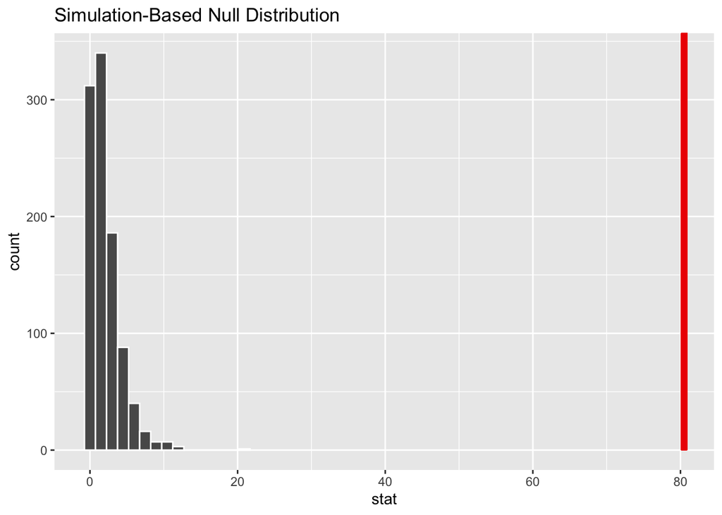

```r
chisq_stat3 = month_data %>%
  specify(Month ~ Revenue) %>%
  calculate(stat = "Chisq")

origin_distribution = month_data %>%
  specify(Month ~ Revenue) %>%
  hypothesize(null = "independence") %>%
  generate(reps = 1000, type = "permute") %>%
  calculate(stat = "Chisq")

visualize(origin_distribution) +
  shade_p_value(obs_stat = chisq_stat3, direction = "greater")
```

While assuming that the two variables month and revenue are independent, the chance of the observed observations falling into upper tail is very low, which can be clean quite clearly with this simulation.